# 新闻分析

Kang

## 概述

主要任务：

- 将新闻文本转换成csv文件。
- 分析每年或每个月的数量变化。
- 对所有文本进行主题分析，解读出文本涉及的若干主题。

## 数量变化

每年和每个月数量变化如下。

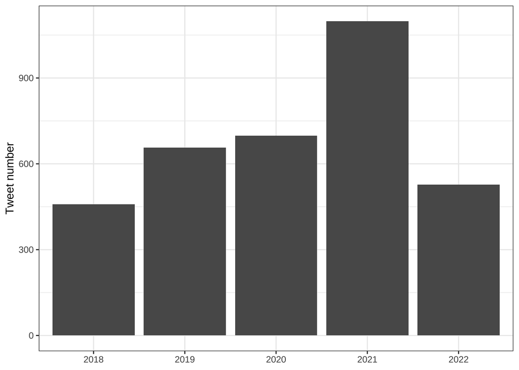

```r
# 每年新闻数量变化。
ash %>%
  group_by(year) %>%
  summarise(n = n(), .groups = "drop") %>%
  ggplot() +
  geom_col(aes(year, n)) +
  labs(x = NULL, y = "Tweet number") +
  theme_bw()
```

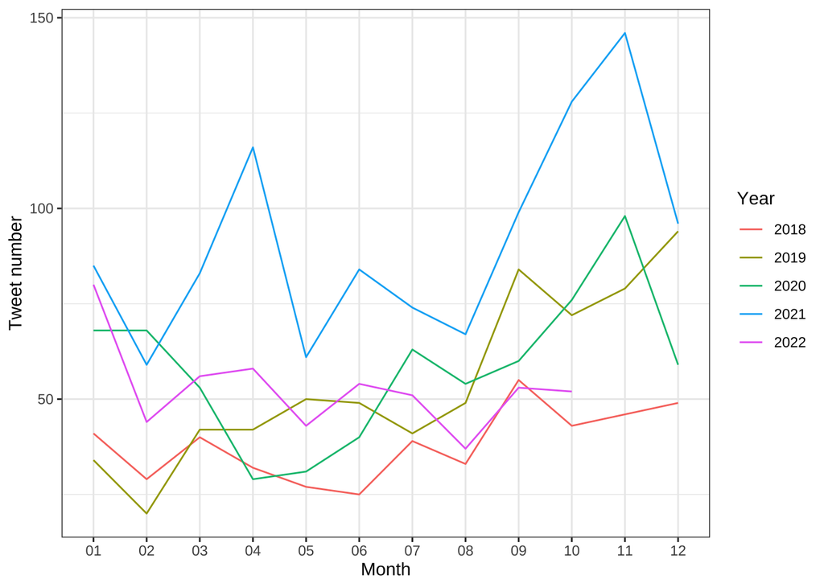

```r
# 每个月新闻数量变化。
ash %>%
  group_by(year, month) %>%
  summarise(n = n(), .groups = "drop") %>%
  ggplot() +
  geom_line(aes(month, n, col = year, group = year)) +
  labs(x = "Month", y = "Tweet number", col = "Year") +
  theme_bw()
```

## 主题分析

文本分析的基本流程为：

（1）先读取所有新闻（我们称每条新闻为”文档”）。

（2）将每个文档进行分词。

（3）去除停止词。

（4）统计词语的频率，同时也可以计算词语的重要性（TF-IDF方法）。

（5）用主题模型对各个文档进行归类，结果呈现为每个文档被划分到各个主题的概率，例如，如果我们希望所有文档被归入3个主题中，那么某个文档属于主题1、2、3的概率可能分别是0.8、0.1、0.1。

用LDA方法对文本进行主题分析，需要先定义主题数量。如果主题数量很少，例如极端情况下（理论上并不合理），我们将所有文档只归入1个主题中，那么所有文档属于该主题的概率就是100%，这种主题划分就没有意义了；再往前一步，如果分成2个主题，如果文档之间有很好的区分度，那没有问题，但是也可能出现大部分文档归入两个主题的概率都差不多是50%，区分度不够高；反之，如果我们将n个文档归入将近n个主题，那每个文档肯定会有所属概率更高的主题类别，但是主题太多，归类的意义也就小了。因此，在定义主题数量的时候，我们希望尽量少，但是又有足够的区分度。

首先看看不同主题数量下，各个文档分属于不同主题的概率。下图中格子颜色表示概率，红色为高概率，绿色为低概率。如果某个子图中，一列中有非常红的红色和大量非常绿的绿色，就表示区分度很好；反之区分度较差。可见各图都是有比较清晰的鲜红色和鲜绿色，区分度都不错。

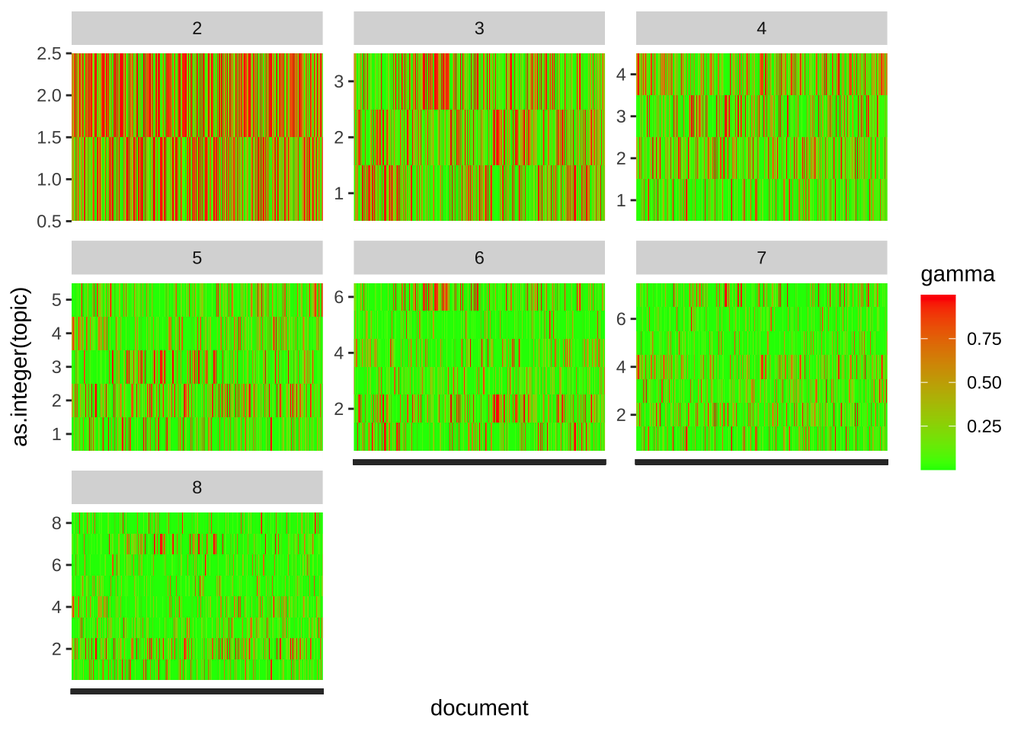

```r
quan_id_topic_test %>%
  bind_rows() %>%
  ggplot() +
  geom_tile(aes(document, as.integer(topic), fill = gamma)) +
  scale_fill_gradient(high = "red", low = "green") +
  theme(axis.text.x = element_blank()) +
  facet_wrap(.~ k, scales = "free_y")
```

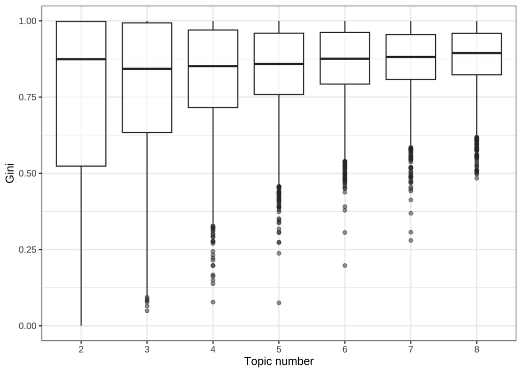

```r
quan_id_topic_test %>%
  group_by(k, document) %>%
  summarise(gini = Gini(gamma), .groups = "drop") %>%
  mutate(k = factor(k, levels = as.character(range_k))) %>%
  ggplot() +
  geom_boxplot(aes(k, gini), alpha = 0.5) +
  theme_bw() +
  labs(x = "Topic number", y = "Gini")
```

用LDA将文本分成8个主题，各个主题的关键词如下。可见还有些词需要合并或者去除。

```r
library(knitr)
library(kableExtra)
topic_word %>%
  kable() %>%
  kable_styling()
```

| topic | term |
| --- | --- |
| 1 | 市, 化, 県, 温暖, 約, 影響, 度, 気象, 水, 観測, 被害, 台風, 気温, 人, 災害, 大, 研究, 地域, 気候, 豪雨, 上昇, 地球, きた, 海, 的, 氷, 以上, メートル, 変動, 日本 \| |
| 2 | 排出, 化, 目標, 国, 日本, ガス, 石炭, エネルギー, 環境, 対策, 気候, 温暖, 削減, 的, 効果, 量, 温室, 原発, 世界, 発電, 炭素, 脱, 企業, 政府, 電力, 変動, ゼ, ロ, 約, 再 \| |
| 3 | 的, 社会, 人, 経済, 日本, 企業, コロナ, 国, 者, 世界, 問題, 化, 必要, たち, 感染, 大学, 課題, できる, 対策, 支援, 成長, 性, 力, 環境, 考え, 投資, 政府, 政策, 危機, 進 \| |
| 4 | 人, たち, 東京, 日本, 見, 五輪, 市, 歳, 世界, 環境, 者, 活動, 化, 感じ, 写真, 県, きた, たい, 気候, 家, 参加, 思, 的, 地球, できる, 食, 会, 若者, 子ども, 考え \| |
| 5 | 的, 研究, 科学, 化, 地球, 大, 世界, 日本, ごみ, プラスチック, 人, 者, 技術, 教授, たち, 問題, 環境, 人間, できる, 使, 温暖, 人類, 開発, 賞, 大学, 社会, きた, 宇宙, 学, 袋 \| |
| 6 | 氏, 党, トランプ, 大統領, 人, 首相, 選挙, 選, 者, 政治, 政権, 民主, 支持, 政策, ン, 米, デ, 院, バイ, 州, 米国, 議員, 対策, 会, 的, 面, 派, 化, 投票, 問題 \| |
| 7 | 中国, 米, 米国, 国, 的, 氏, ン, 政権, デ, 国際, バイ, 日本, 大統領, 世界, 問題, 首脳, 関係, 気候, トランプ, 経済, 変動, ロシア, 欧州, 首相, 協力, 会談, 会議, 外交, 政府, 安全 \| |
| 8 | 環境, 原発, 日本, 生物, 世界, 地球, 自然, 大, 性, 写真, 海, 東京, 多様, 開発, 事故, 森林, たち, 教授, 問題, 保護, 者, コーディネーター, 国際, 研究, 社会, 的, 可能, 本社, 気候, 持続 \| |